# ACP

S’observa que la base de dades té un total de 8 columnes numèriques. Per tant, l’anàlisi de components principals tindrà 8 components.

```
##               age      grades_sem_1     no_eval_sem_1      grades_sem_2
##         "numeric"         "numeric"         "numeric"         "numeric"
##     no_eval_sem_2 unemployment_rate    inflation_rate               gdp
##         "numeric"         "numeric"         "numeric"         "numeric"
```

Els resultats de l’anàlisi de components principals sobre les variables numèriques són els següents:

```
## Standard deviations (1, .., p=8):
## [1] 1.3948881 1.2413107 1.1457856 1.0041560 0.9685334 0.8028912 0.6383884
## [8] 0.4494999
##
## Rotation (n x k) = (8 x 8):
##                           PC1         PC2         PC3         PC4         PC5
## age                0.24586659  0.03529476 -0.04350367  0.03379747 -0.96650110
## grades_sem_1      -0.59978174 -0.32227631 -0.07909503  0.05747587 -0.17266379
## no_eval_sem_1      0.30271755 -0.61710448  0.13456221  0.05090417  0.05602916
## grades_sem_2      -0.60281108 -0.32703352 -0.04403668  0.05853729 -0.14805220
## no_eval_sem_2      0.30585628 -0.60477416  0.14291011  0.04943162  0.05057019
## unemployment_rate  0.04184307 -0.05563562 -0.68285536 -0.33822281  0.04639942
## inflation_rate     0.03680361  0.09645898 -0.20770896  0.93197266  0.06274800
## gdp               -0.16774671  0.17021150  0.66479128 -0.06422781 -0.04854441
##                            PC6          PC7          PC8
## age                0.026553270  0.009832622  0.018518454
## grades_sem_1      -0.007957304 -0.016242952 -0.704769753
## no_eval_sem_1     -0.038854424  0.708477929 -0.016000326
## grades_sem_2      -0.014794349  0.003771702  0.708625067
## no_eval_sem_2      0.231872481 -0.679328477  0.004898898
## unemployment_rate  0.630751286  0.118979092  0.017652568
## inflation_rate     0.266673044  0.050541810  0.004337384
## gdp                0.689040290  0.139594434 -0.014026455
```

Cada component representa una inèrcia concreta. S’explica el percentatge d’inèrcia que representa cada component.

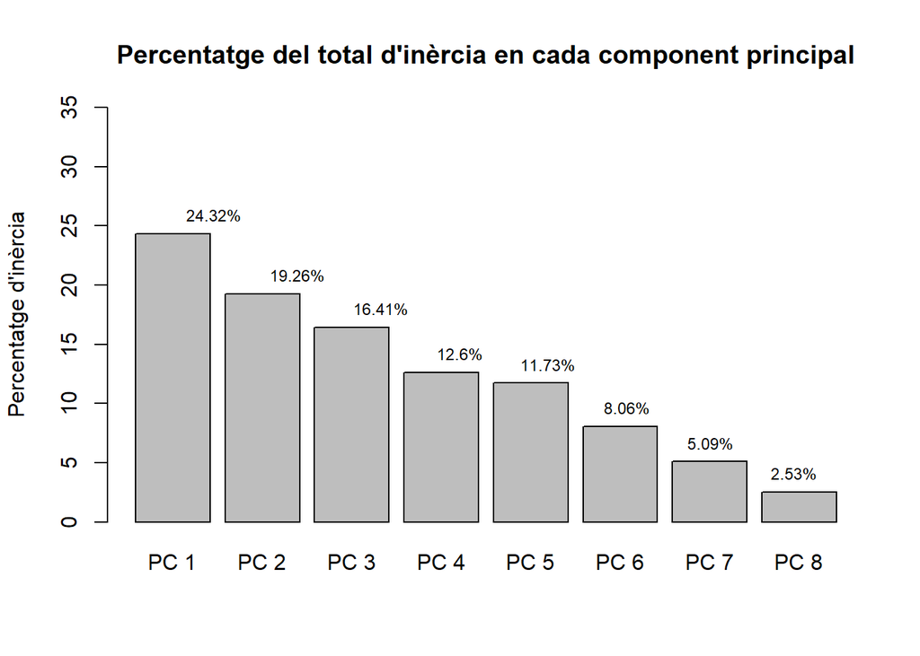

Es veu que la primera component representa el 24.32% de la inèrcia, la segona el 19.26%, la tercera el 16.41%, la quarta el 12.6%, la cinquena el 11.73%, la sisena el 8.06%, la setena el 5.09% i, la vuitena el 2.53%.

Interessa també la inèrcia acumulada:

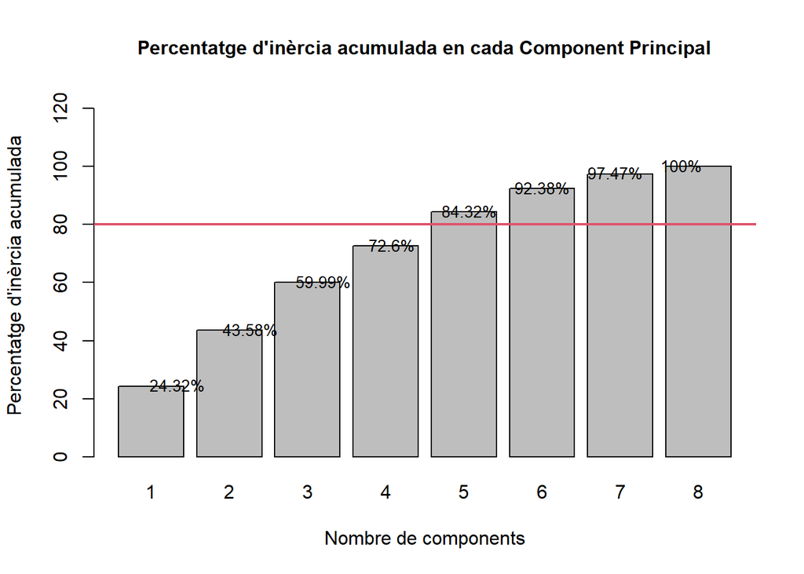

Tenint en compte que la inèrcia equival a la proporció de la variabilitat de les dades, se sap que amb un 80% d’inèrcia, es pot obtenir gairebé tota la informació o variabilitat de la base de dades original. En el gràfic de la inèrcia acumulada es pot veure que amb les 4 primeres components ja s’aconsegueix gairebé el 80% de la inèrcia. Si es pren les 5 primeres components, el total de variabilitat que s’aconsegueix explicar és del 84.32%. Ens quedem amb les components PC1, PC2, PC3, PC4 i PC5.

Es realitza un gràfic de dispersió per a totes les combinacions possibles:

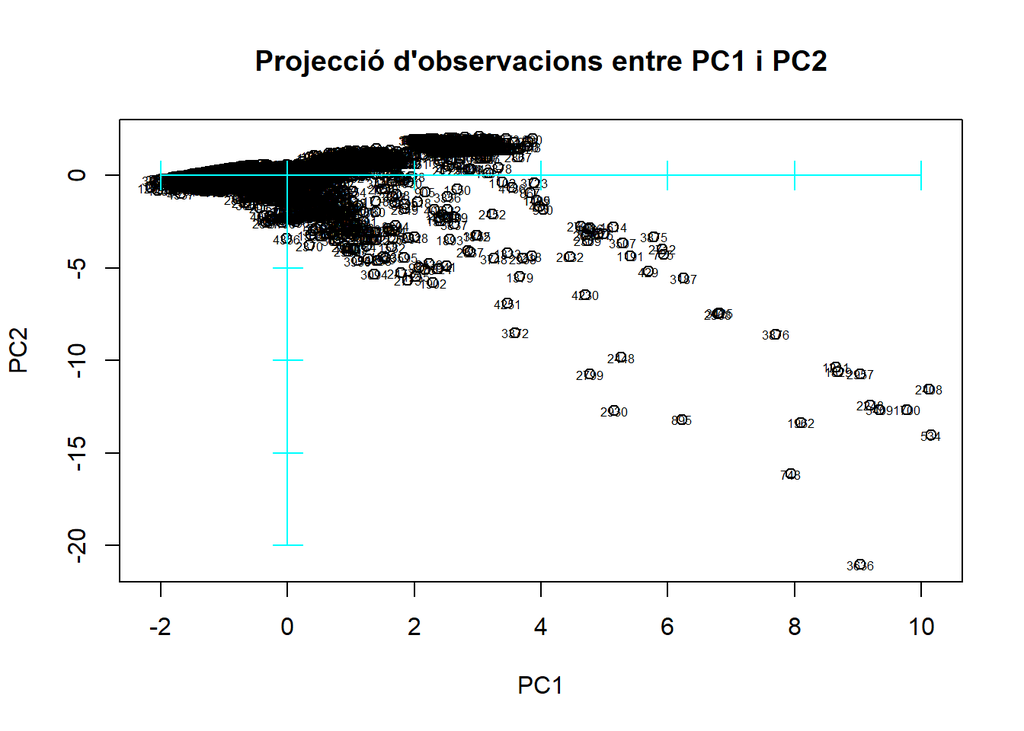

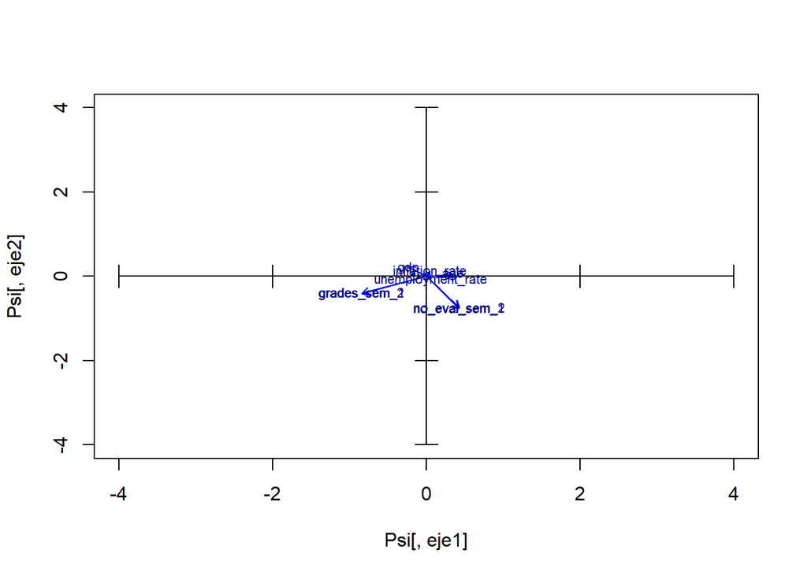

## Projecció de les variables numèriques

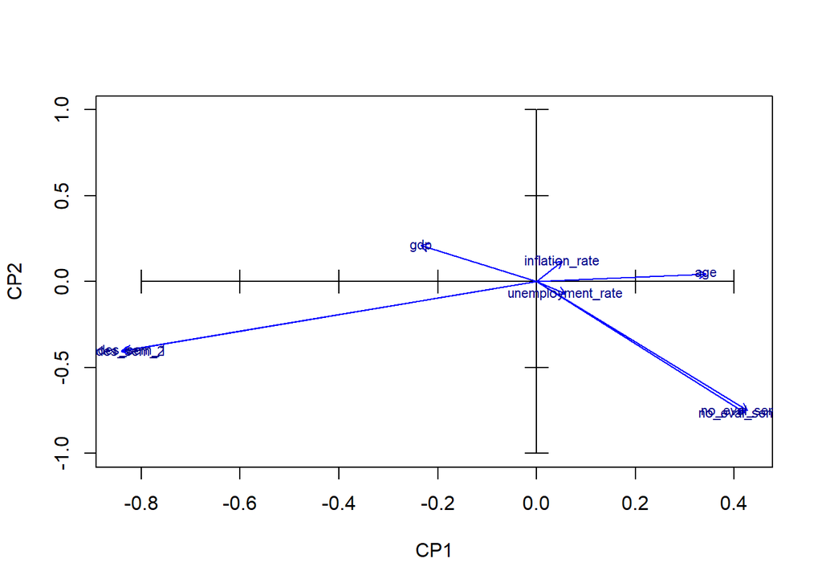

Les variables que representen les notes dels semestres i les variables que fan referència a les unitats no avaluables són les que tenen més variabilitat continguda en la representació dels dues components del biplot. Així mateix, s’observa que l’edat ha contribuït bastant a la component 1, ja que es veu com el vector paral·lel a l’eix de la component 1.

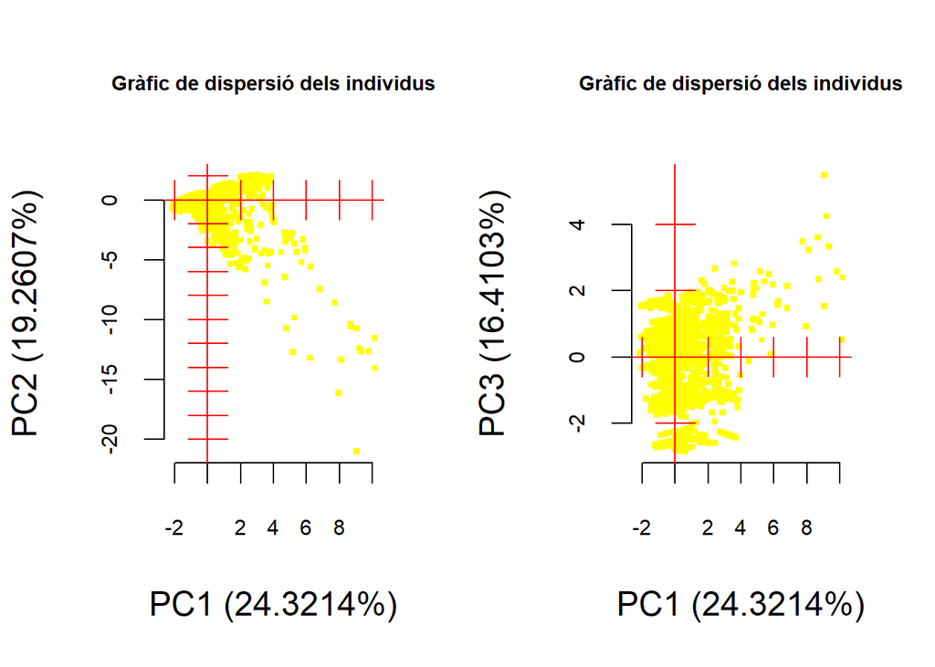

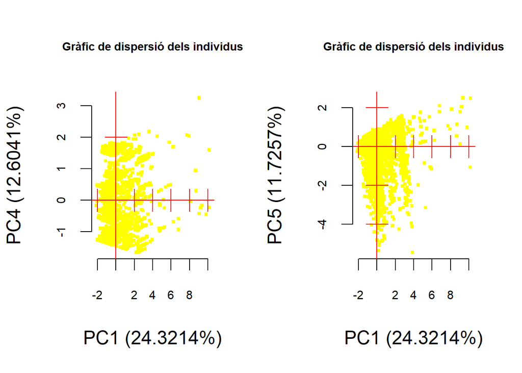

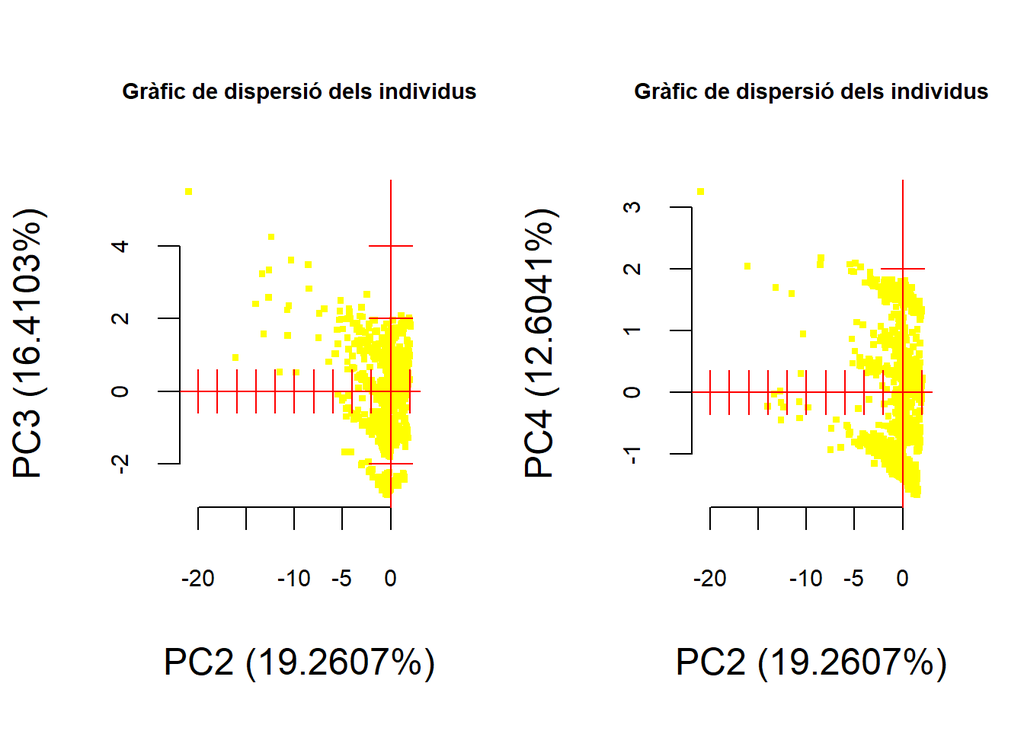

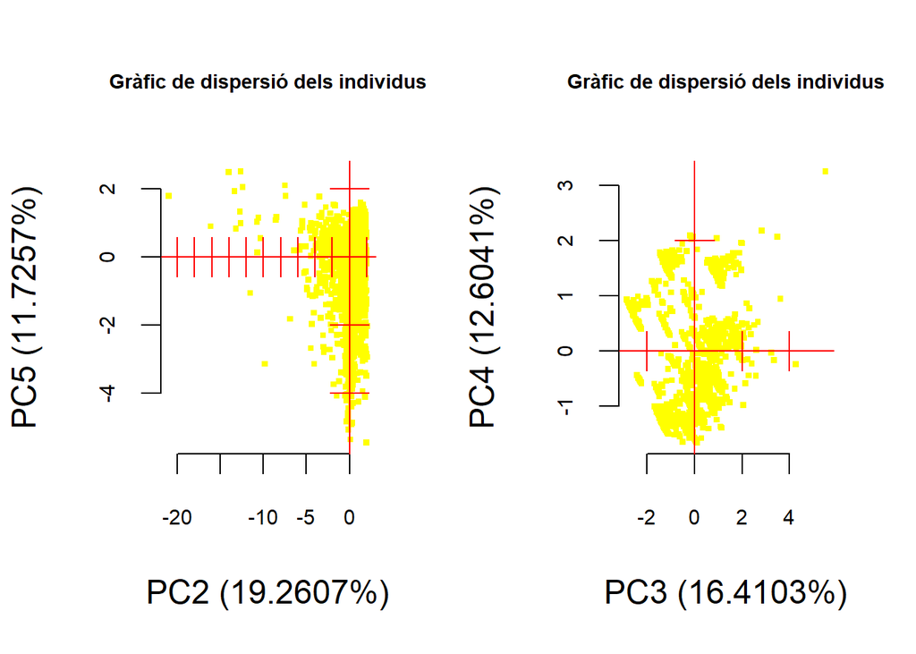

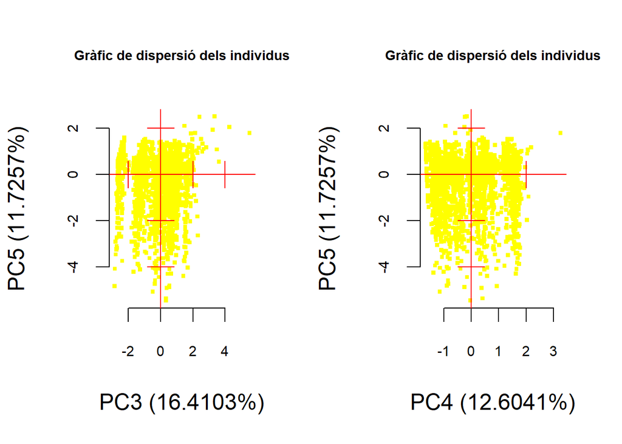

## Projecció de les variables categòriques

Variables categòriques

```
##                 course     daytime_attendance previous_qualification
##                      1                      2                      3
##            nationality      occupation_mother      occupation_father
##                      4                      5                      6
##          special_needs                 gender            scholarship
##                      7                      8                      9
##                 target
##                     18
```

Si en el mateix gràfic s’afegeixen totes les modalitats de totes les variables categòriques, s’obté el següent:

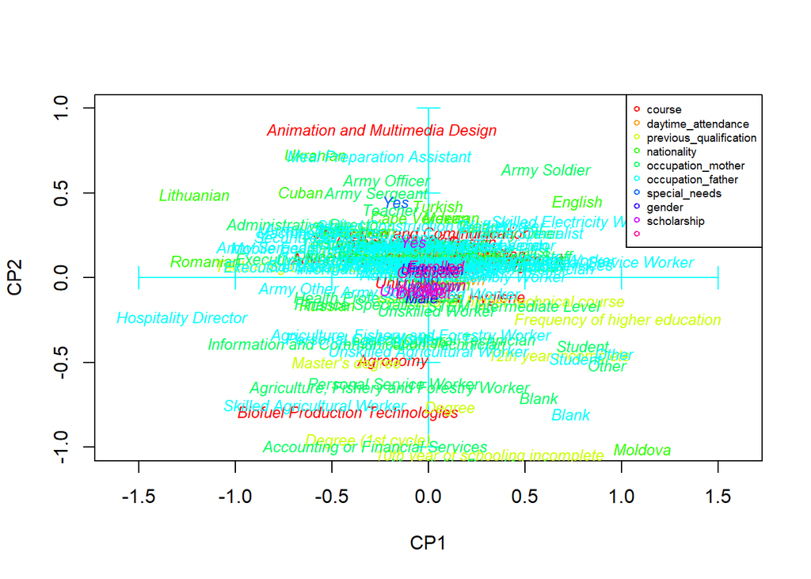

Aquest gràfic no es pot interpretar, ja que en tenir tantes modalitats aquestes no es poden distingir.

Es limita el nombre màxim de modalitats a 8 per variable. A més a més, s’escurcen els noms d’algunes modalitats per tal que siguin llegibles al gràfic. Es repeteix aquest procediment per a les següents variables categòriques: course, previous qualification, nationality, occupation mother i occupation father, que són les que tenen més modalitats.

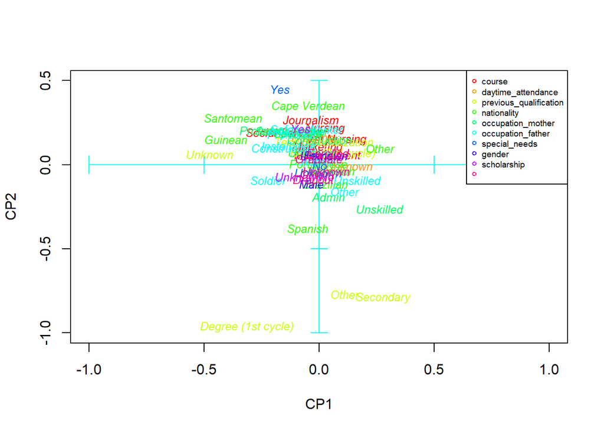

Es crea un gràfic per a cada variable categòrica:

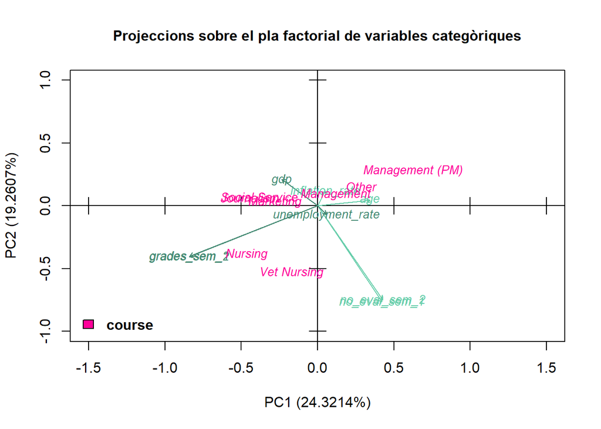

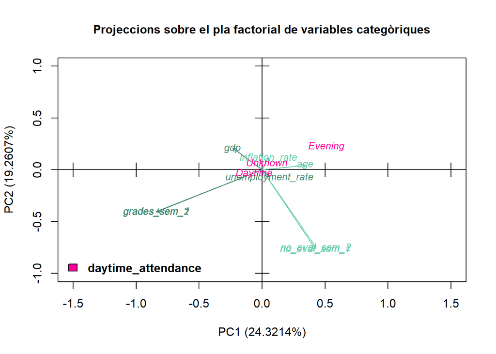

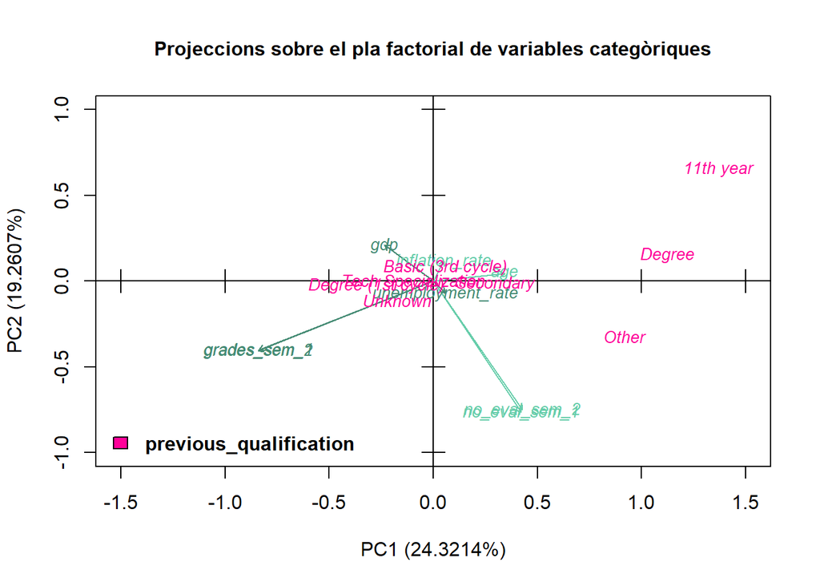

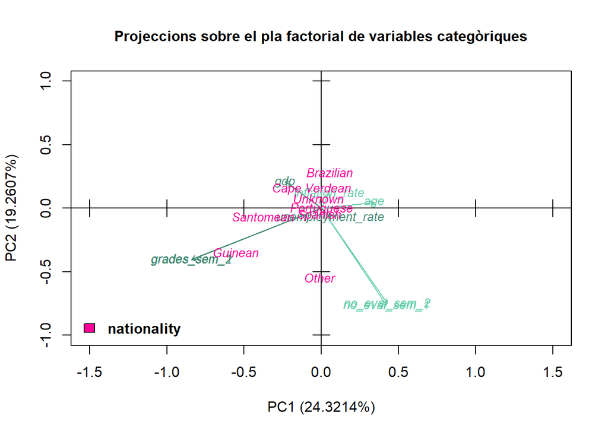

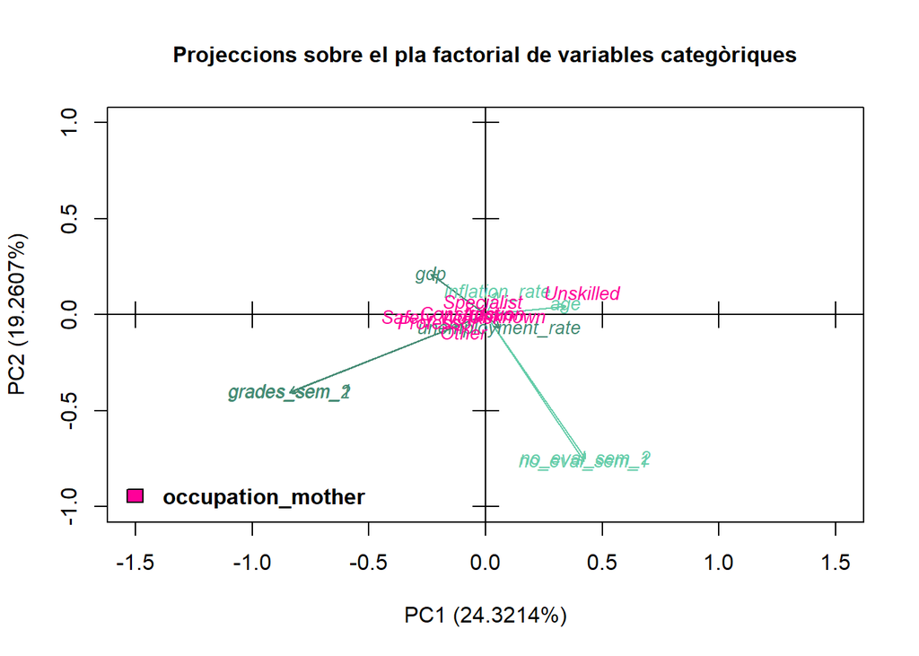

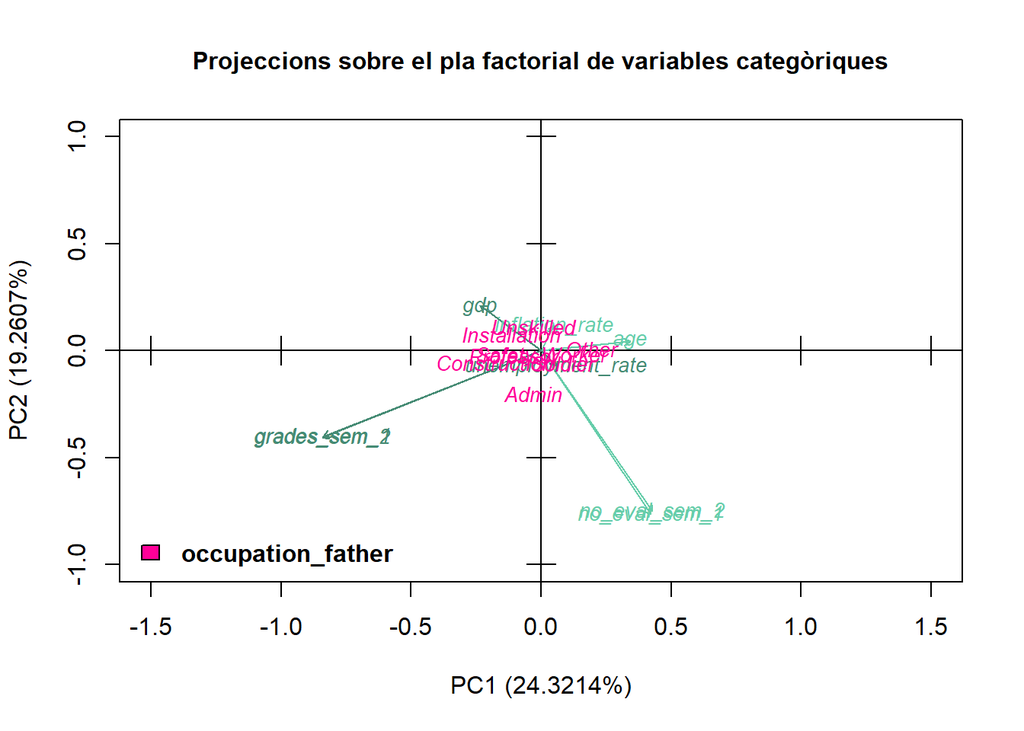

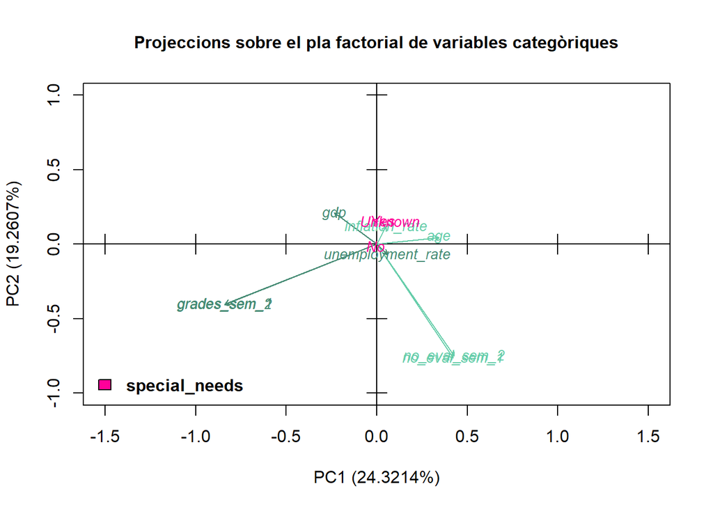

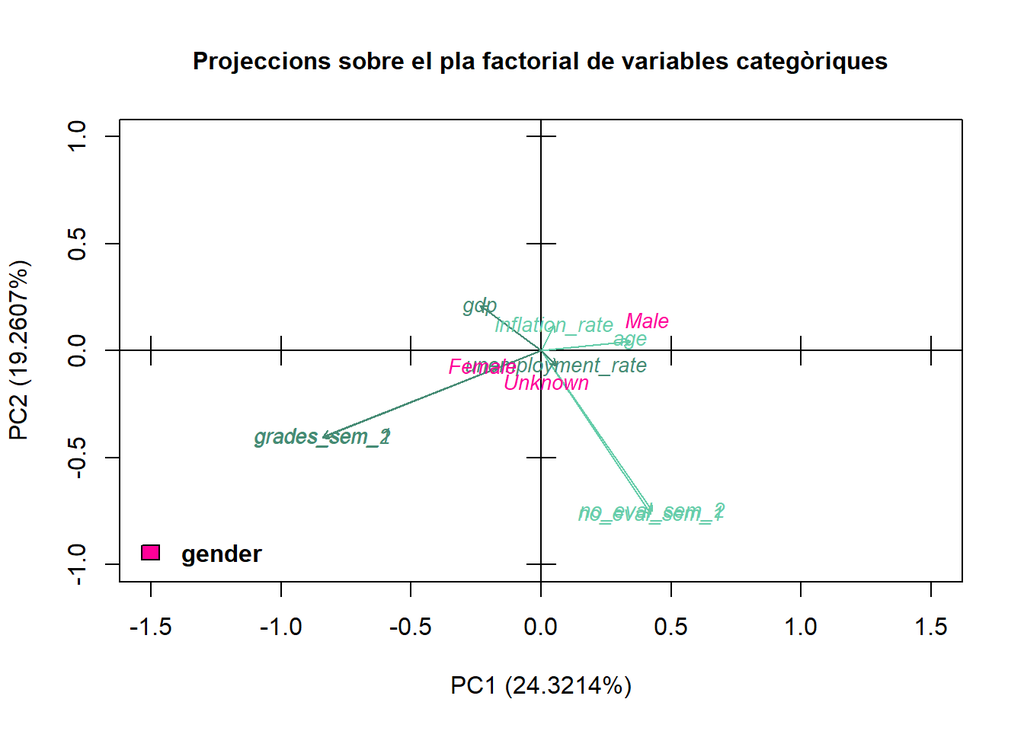

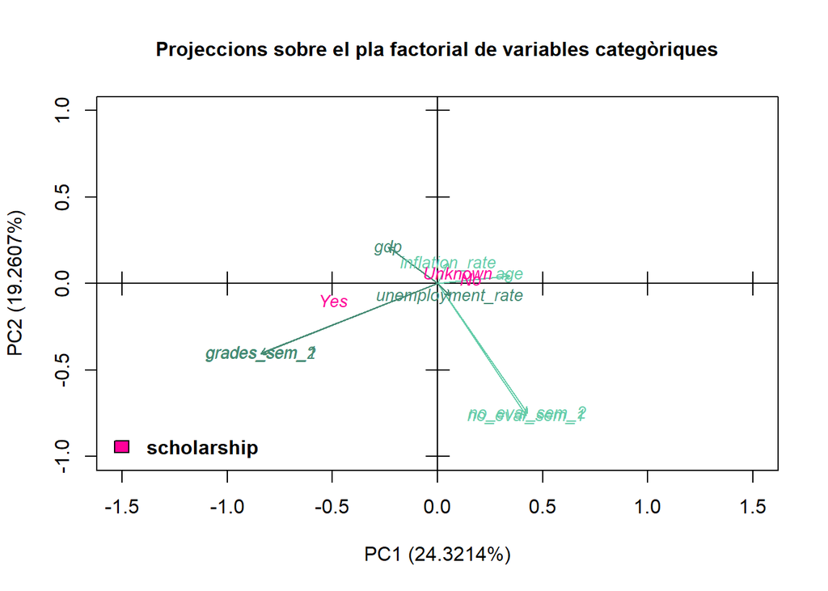

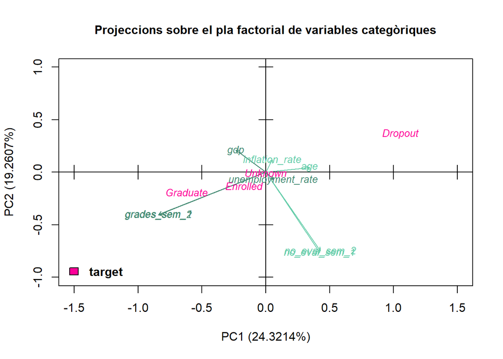

Per a la variable **course**, es veu que la majoria de les modalitats de la variable es troben molt a prop de l’origen, fet que implica que expliquen les dues components de manera similar però amb una baixa contribució sobre les components. Destaca la modalitat Vet Nursing, que explica la segona component, ja que es troba tot just a sobre de l’eix d’ordenades. Nursing té angles molt similars amb la primera i la segona component, per tant, es pot dir que les expliquen d’igual manera.

Per a la variable **nationality**, la modalitat Other explica perfectament la segona component, ja que es troba exactament a sobre de l’eix d’ordenades. La modalitat Guinean forma un angle similar amb totes dues components. La majoria de les modalitats de la variable **occupation_mother** expliquen totes dues components per igual, però hi tenen una contribució molt baixa, ja que es troben molt properes a l’origen.

El mateix es pot dir per a la variable **occupation_father** excepte per la modalitat Admin, que en trobar-se sobre l’eix d’ordenades i no sobre el de coordenades explica la segona component.

Pel que fa a les modalitats de la variable **special_needs**, es veu que només la modalitat No es troba sobre l’origen i que Yes i Unknown només expliquen la segona component.

La modalitat No de la variable **scholarship** explica la primera component a trobar-se just a sobre de l’eix de coordenades. No obstant això, té una contribució molt baixa sobre aquesta component, ja que es troba bastant propera a l’origen.